# Hope and Optimism: Essential and Migrant Workers

Monique Estrada

2023-08-08

```r
#Load in the data
rawData<-read.csv("Estrada ARC Coding.csv")

data<-rawData
```

```r
#Restructure the data
data <- subset(data, select = -c(17:30))


data$Edu<- factor (data$Education,labels = c("Primary","High School",
                                             "Some College","Currently Enrolled",
                                             "Associates", "Undergraduate"))


data$Hopeall<-factor(data$HOPE, labels = c ( "Either Cognitive or Affective",
                                            "Both"))


data$Optimismall<-factor(data$Optimism, labels = c ("Personal Growth",
                                                    "Either Gratitude and Perspective",
                                                    "Both"))
```

# Overview

## Background:

Migrant workers in the U.S. faced disproportionate affects during the pandemic.

One third of our migrant workers identify as essential workers. Migrant workers experienced burnout during the pandemic (which reduces well-being) as well as uncertainty involving legalities of employment and separation from family. Well-being is positively associated with workplace satisfaction, productivity, and overall societal resilience.

## Significance:

COVID-19 was a testament to the role that our migrant essential workers play in our society. They proved to be the fabric of our social and economic infrastructure. The well-being of our migrant essential workers is thus necessary to address because of the resulting reports of decreased well-being during the pandemic.

## Purpose:

For this exploratory study, we want to understand how Psychological Capital was utilized by migrant essential workers in order to identify strengths and areas of improvement to support work environments.

## Hypothesis:

This report presents preliminary data analysis for the types and levels of hope that our migrant essential workers expressed in relation to their level of education.

1. Interviews will consist of more affective hope when education level is higher
2. Interviews will consist of more the agency component of hope if education level is higher.
3. Interviews will consist more of the pathway component of hope if education level is higher.

# Methods

To do this we will observe Psychological Capital (PsyCap) through:

Coding 16 of 40 in depth interviews of migrant essential workers in Santa Barbara County.

-Thematic coding will be utilized for analysis of PsyCap

## Demographics

62.5% Female 37.5% Male

81.3% identified as Latinx

Majority had an education level of high school degree or lower Made less than $60,000

# Psychological Capital

Is a higher order construct which consists of four elements (HERO):

### Hope

(Goal Oriented)

Requires a sense of agency and pathway, which provide people with an internalized determination and willpower to invest the energy of achieving the goal

Agency: Motivation

Pathway: Planning

Key takeaway:

The more pathways to achieving a goal, the more motivation we continue to build to achieve a goal, they work hand in hand.

### Efficacy

The confidence in one’s own ability to reach a particular goal.

### Resilience

The positive adaptation from adversity.

### Optimism

The Psychological intention and expectation of positive future outcomes.

# Hope Analysis

## Prediction 1

Prediction 1 was not supported, there is no significant relationship between level of education and the expression of Affective Hope.

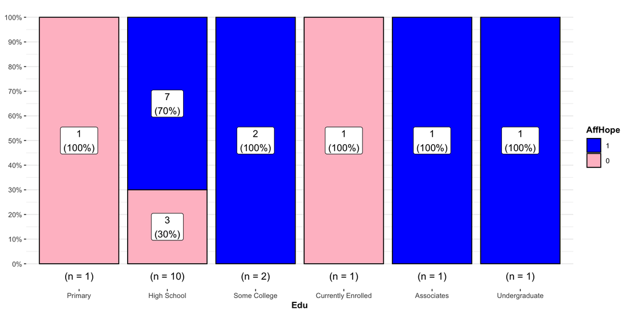

```r
#Create Chi-square table for Education and Affective Hope
contingency_tableaffhope <- table(data$Edu, data$AffHope)
ggbarstats(
  data  = data,
  x     = "AffHope",
  y     = "Edu",
  label = "both",
  results.subtitle=F
  ) + scale_fill_manual(values=c("blue", "pink"))
```

```r
#Create Chi-Square table for Education and Affective Hope
fisher.test(contingency_tableaffhope)
```

```
##
##  Fisher's Exact Test for Count Data
##
## data:  contingency_tableaffhope
## p-value = 0.4341
## alternative hypothesis: two.sided
```

## Prediction 2

Prediction 2 was not supported, there was no significant relationship between level of education and the expression of the Agency (motivation) component of Hope.

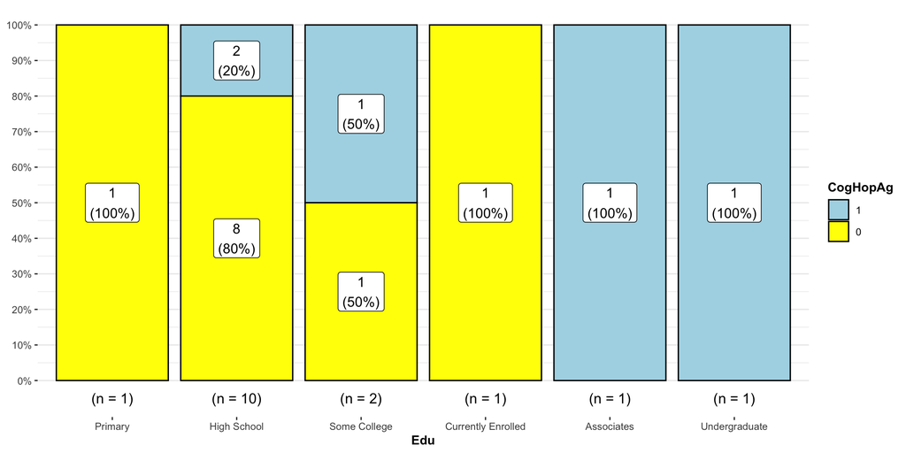

```r
#Create Chi-square table for Education and Cognitive Hope (Agency)
contingency_tablecoghopeagency<- table(data$Edu, data$CogHopAg)
ggbarstats(
  data  = data,
  x     = "CogHopAg",
  y     = "Edu",
  label = "both",
  results.subtitle=F
  ) + scale_fill_manual(values=c("lightblue", "yellow"))
```

```r
#Create Chi-Square table for Education and Cognitive Hope (Agency)
fisher.test(contingency_tablecoghopeagency)
```

```
##
##  Fisher's Exact Test for Count Data
##
## data:  contingency_tablecoghopeagency
## p-value = 0.2418
## alternative hypothesis: two.sided
```

## Prediction 3

Predicion 3 was not supported, there was no significant relationship between level of education and the expression of the Pathway (planning) component of hope.

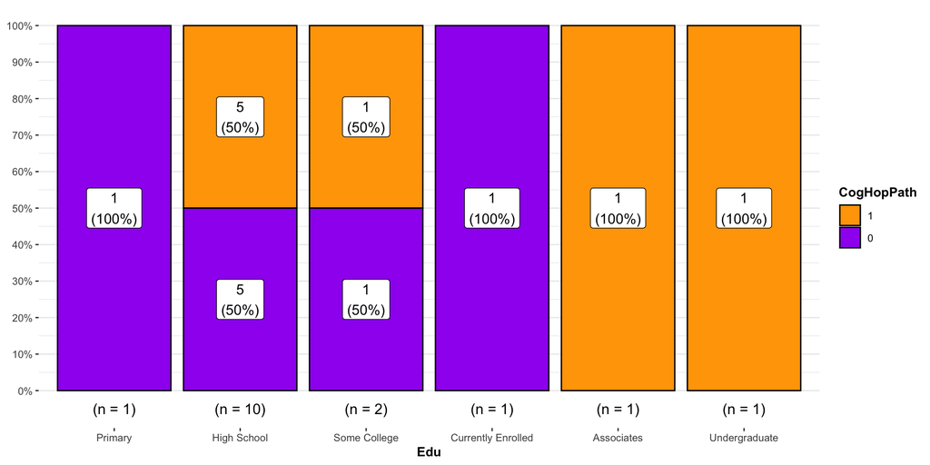

```r
#Create Chi-square table for Education and Cognitive Hope Pathway
contingency_tablecoghopepath<- table(data$Edu, data$CogHopPath)
ggbarstats(
  data  = data,
  x     = "CogHopPath",
  y     = "Edu",
  label = "both",
  results.subtitle=F
  ) + scale_fill_manual(values=c("orange", "purple"))
```

```r
#Create Chi-Square table for Education and Cognitive Hope Pathway
fisher.test(contingency_tablecoghopepath)
```

```
##
##  Fisher's Exact Test for Count Data
##
## data:  contingency_tablecoghopepath
## p-value = 1
## alternative hypothesis: two.sided
```

# Future Steps

To continue to analyze and code all migrant essential worker interviews for levels of Psychological capital and compare groups based off of parameters set on education and income.